# Timing matters: Viticultural land use determines responses in structure and function of fungal stream communities across one growing season

#### 3.2.2.1 create RDA Figure S9 c

```r
scl = 'symmetric'
# arrange size of single plot
si_sc <- scores(rda_DNA_5, choices = 1:2, scaling = scl, display = 'sites')
sp_sc <- scores(rda_DNA_5, choices = 1:2, scaling = scl, display = 'species')
va_sc <- scores(rda_DNA_5, choices = 1:2, scaling = scl, display = 'cn')

scrs <- scores(rda_DNA_5, display = c("sites"), scaling = scl)

png(filename="Figure_S9_c_RDA_DNA_all_fungi.png", width=15, height=15, pointsize=10, units = "cm", res = 800)
p_DNA <- plot(rda_DNA_5,
          scaling = 'symmetric',
          type = 'n',
          xlab =
            paste(attributes(summary(rda_DNA_5)$cont$importance)$dimnames[[2]][1],
                     " (", round(summary(rda_DNA_5)$cont$importance[2,1]*100),
                     "% total variance)", sep=""),
          ylab =
            paste(attributes(summary(rda_DNA_5)$cont$importance)$dimnames[[2]][2],
                     " (", round(summary(rda_DNA_5)$cont$importance[2,2]*100),
                     "% total variance)", sep=""),
          xlim = c(min(scrs[,1]) + ((8/10) *  min(scrs[,1])), max(scrs[,1])),
          # at min space added for legend
          ylim = c(min(scrs[,2]) + ((1/10) *  min(scrs[,2])), max(scrs[,2]) + ((1/10) *  max(scrs[,2]))),
          main = "all fungi ASV", cex.lab = 1.5, cex.axis = 1.5, cex.main = 1.5)

# add points colored by fungicide treatment
cols <- c("#19A1BF","#0000EE", "#F00303")
# points shaped by cycle
pchs <- c(16, 17, 15, 18)
points(si_sc,
       col = cols[DNA_expl$treatment],  # color by treatment
       pch = pchs[DNA_expl$timepoint],      # shape by  timepoint
       cex = 1.5)

# don't add legend as this is already in figure a

# add Figure letter
mtext("(c)", side = 3, line = 1, adj = 0, cex = 2)

# connect single points per fungicide treatment and cycle
ordihull(p_DNA, interaction(DNA_expl$timepoint, DNA_expl$treatment),
           col = rep(cols, each = 4), label = F, draw = "polygon", border = rep(cols, each = 4))
dev.off()
```

### 3.2.3 ASVs richness of all fungi

calculate richness of determined Amplicon Sequence Variants (ASVs) (i.e. all detected ASVs in one sample)

```r
DNA$ASV_rich <- apply(DNA[7:ncol(DNA)], 1, function(x) sum(x > 0))
```

```r
ASV <- DNA[ , c("Stream", "treatment", "timepoint", "ASV_rich")]

ASV_lmer1 <- glmer(ASV_rich ~ timepoint + treatment + timepoint:treatment + (treatment|Stream), data = ASV, family = "poisson")

drop1(ASV_lmer1, test = 'Chisq')
```

```
## Single term deletions
##
## Model:
## ASV_rich ~ timepoint + treatment + timepoint:treatment + (treatment |
##     Stream)
##                     npar    AIC    LRT Pr(Chi)
## <none>                   1322.2
## timepoint:treatment    6 1325.8 15.653 0.01574 *
## ---
## Signif. codes:  0 '***' 0.001 '**' 0.01 '*' 0.05 '.' 0.1 ' ' 1
```

```r
# interaction is significant p = 0.01574
anova(ASV_lmer1)
```

```
## Analysis of Variance Table
##                     npar  Sum Sq Mean Sq F value
## timepoint              3 18.0890  6.0297  6.0297
## treatment              2  2.9949  1.4974  1.4974
## timepoint:treatment    6 15.6888  2.6148  2.6148
```

```r
ASV_inter <- lsmeans(ASV_lmer1, ~ treatment | timepoint )

ASV_inter_dunn1 <- contrast(ASV_inter, 'pairwise')
(ASV_inter_dunn_sum1 <- summary(ASV_inter_dunn1, infer = TRUE, adjust = 'mvt'))
```

```
## timepoint = April:
##  contrast            estimate    SE  df asymp.LCL asymp.UCL z.ratio p.value
##  forest - transplant  -0.1543 0.124 Inf    -0.446   0.13718  -1.240  0.4292
##  forest - viti        -0.2338 0.130 Inf    -0.539   0.07165  -1.793  0.1716
##  transplant - viti    -0.0795 0.125 Inf    -0.373   0.21369  -0.635  0.8005
##
## timepoint = June:
##  contrast            estimate    SE  df asymp.LCL asymp.UCL z.ratio p.value
##  forest - transplant   0.0587 0.127 Inf    -0.240   0.35739   0.460  0.8898
##  forest - viti        -0.1167 0.132 Inf    -0.427   0.19317  -0.883  0.6512
##  transplant - viti    -0.1753 0.130 Inf    -0.480   0.12951  -1.348  0.3685
##
## timepoint = August:
##  contrast            estimate    SE  df asymp.LCL asymp.UCL z.ratio p.value
##  forest - transplant   0.0721 0.127 Inf    -0.226   0.37069   0.566  0.8380
##  forest - viti        -0.2207 0.131 Inf    -0.529   0.08742  -1.679  0.2133
##  transplant - viti    -0.2929 0.128 Inf    -0.593   0.00729  -2.287  0.0577
##
## timepoint = September:
##  contrast            estimate    SE  df asymp.LCL asymp.UCL z.ratio p.value
##  forest - transplant  -0.2502 0.148 Inf    -0.597   0.09652  -1.692  0.2081
##  forest - viti        -0.2711 0.153 Inf    -0.629   0.08710  -1.774  0.1780
##  transplant - viti    -0.0209 0.141 Inf    -0.352   0.31038  -0.148  0.9880
##
## Results are given on the log (not the response) scale.
## Confidence level used: 0.95
## Conf-level adjustment: mvt method for 3 estimates
## P value adjustment: mvt method for 3 tests
```

- April:
  - no significant difference
- June:
  - no significant difference
- August
  - tendency between transplant and viti
- September:
  - no significant difference

#### 3.2.3.1 create Figure S6 d

create plot of ASV richness

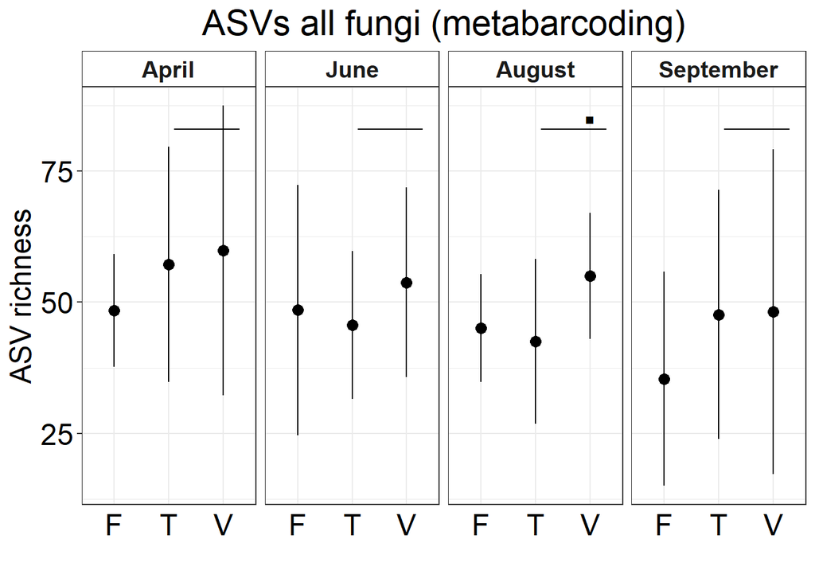

```r
ASV_CI <- group.CI(ASV_rich ~ timepoint + treatment,
                   data = DNA,
                   ci = 0.95)

# change order of factor
ASV_CI$time.point <- factor(ASV_CI$timepoint,
                             levels = c("April", "June", "August", "September"))

# rename transplant treatments in order to enable fit to the plot
ASV_CI$treatment <- gsub("transplant", "T", ASV_CI$treatment)
ASV_CI$treatment <- gsub("viti", "V", ASV_CI$treatment)
ASV_CI$treatment <- gsub("forest", "F", ASV_CI$treatment)

# add one tendency to plot
taxa_text <- data.frame(treatment = "V", ASV_rich.mean = 85, lab = "\U25AA",
                       time.point = factor("August",levels = c("April", "June", "August", "September")))
# Difference trans. - viti August
mv_taxa <- data.frame(a = c(2.1, 2.5, 3, 3.3), b = rep(c(83), 4))


p1_ASV <-  ggplot(ASV_CI, aes(x = treatment, y = ASV_rich.mean)) +
  geom_pointrange(data = ASV_CI, aes(y = ASV_rich.mean, ymin = ASV_rich.lower, ymax = ASV_rich.upper))+
  geom_point(data = ASV_CI, mapping = aes(y = ASV_rich.mean), size = 3) +
  facet_wrap(~time.point, nrow = 1) +
  ylab('ASV richness')+
  xlab("")+
  ggtitle("ASVs all fungi (metabarcoding)")+
  #ylim(2, 22)+
  geom_text(data = taxa_text, label = taxa_text$lab, cex = 7) +#, x = taxa_text$treatment, y = taxa_text$DLM.mean) +
  geom_line(data = mv_taxa, aes(x = a, y = b)) +
  theme_bw()+
  theme(axis.text.x = element_text(size = 18, color="black"), axis.ticks.x = element_blank(),
         axis.text.y = element_text(colour="black", size = 18),
         legend.position="none", strip.text.x = element_text(face = "bold"),
         text = element_text(size=18), plot.title =  element_text(hjust = 0.5),strip.background = element_rect(fill="white"))

p1_ASV
```

```r
# remove additional lines manually in vector graph
```

### 3.2.4 community composition only hyphomycetes ASVs

based on metabarcoding #### make Anovas Create several Anovas with different numbers and composition of explanatory variables, to be able to calculate effects sizes and p-values individually for each explanatory variable.

```r
rda_DNA_hyph_1 <- rda(decostand(DNA_hyph, "hellinger")
                        ~ timepoint +  Condition(Stream), data = DNA_expl)
summary(rda_DNA_hyph_1, display = NULL)
```

```
##
## Call:
## rda(formula = decostand(DNA_hyph, "hellinger") ~ timepoint +      Condition(Stream), data = DNA_expl)
##
## Partitioning of variance:
##               Inertia Proportion
## Total         0.63701     1.0000
## Conditioned   0.22482     0.3529
## Constrained   0.07082     0.1112
## Unconstrained 0.34137     0.5359
##
## Eigenvalues, and their contribution to the variance
## after removing the contribution of conditiniong variables
##
## Importance of components:
##                          RDA1    RDA2     RDA3     PC1     PC2     PC3     PC4
## Eigenvalue            0.05728 0.01153 0.002011 0.07697 0.04212 0.02675 0.02221
## Proportion Explained  0.13896 0.02797 0.004879 0.18672 0.10218 0.06489 0.05387
## Cumulative Proportion 0.13896 0.16693 0.171809 0.35853 0.46071 0.52560 0.57947
##                           PC5     PC6     PC7     PC8     PC9     PC10     PC11
## Eigenvalue            0.01862 0.01824 0.01321 0.01246 0.01122 0.009979 0.007994
## Proportion Explained  0.04517 0.04424 0.03205 0.03023 0.02722 0.024209 0.019395
## Cumulative Proportion 0.62464 0.66888 0.70094 0.73116 0.75839 0.782598 0.801993
##                           PC12     PC13     PC14    PC15     PC16     PC17
## Eigenvalue            0.007752 0.007586 0.005821 0.00512 0.004955 0.004714
## Proportion Explained  0.018806 0.018405 0.014121 0.01242 0.012022 0.011436
## Cumulative Proportion 0.820799 0.839204 0.853325 0.86575 0.877767 0.889203
##                           PC18     PC19     PC20     PC21     PC22     PC23
## Eigenvalue            0.004322 0.003782 0.003361 0.002988 0.002765 0.002399
## Proportion Explained  0.010485 0.009176 0.008154 0.007249 0.006708 0.005821
## Cumulative Proportion 0.899689 0.908865 0.917018 0.924268 0.930976 0.936797
##                           PC24     PC25     PC26     PC27     PC28     PC29
## Eigenvalue            0.002132 0.001949 0.001780 0.001587 0.001362 0.001357
## Proportion Explained  0.005172 0.004729 0.004319 0.003851 0.003304 0.003293
## Cumulative Proportion 0.941969 0.946698 0.951017 0.954868 0.958171 0.961464
##                           PC30     PC31     PC32     PC33      PC34      PC35
## Eigenvalue            0.001312 0.001193 0.001096 0.000909 0.0009017 0.0008215
## Proportion Explained  0.003183 0.002893 0.002660 0.002205 0.0021876 0.0019931
## Cumulative Proportion 0.964647 0.967541 0.970200 0.972405 0.9745931 0.9765862
##                            PC36      PC37      PC38      PC39      PC40
```

[output cut: 39 more lines]

```
##                            PC86      PC87      PC88      PC89      PC90
## Eigenvalue            4.703e-06 3.739e-06 2.972e-06 1.753e-06 1.241e-06
## Proportion Explained  1.141e-05 9.070e-06 7.209e-06 4.253e-06 3.011e-06
## Cumulative Proportion 1.000e+00 1.000e+00 1.000e+00 1.000e+00 1.000e+00
##                            PC91      PC92
## Eigenvalue            9.701e-07 7.893e-08
## Proportion Explained  2.353e-06 1.915e-07
## Cumulative Proportion 1.000e+00 1.000e+00
##
## Accumulated constrained eigenvalues
## Importance of components:
##                          RDA1    RDA2     RDA3
## Eigenvalue            0.05728 0.01153 0.002011
## Proportion Explained  0.80881 0.16279 0.028401
## Cumulative Proportion 0.80881 0.97160 1.000000
```

```r
anova(rda_DNA_hyph_1, by = "margin")
```

```
## Permutation test for rda under reduced model
## Marginal effects of terms
## Permutation: free
## Number of permutations: 999
##
## Model: rda(formula = decostand(DNA_hyph, "hellinger") ~ timepoint + Condition(Stream), data = DNA_expl)
##           Df Variance      F Pr(>F)
## timepoint  3  0.07082 6.3618  0.001 ***
## Residual  92  0.34137
## ---
## Signif. codes:  0 '***' 0.001 '**' 0.01 '*' 0.05 '.' 0.1 ' ' 1
```

```r
# timepoint  3  0.07082 6.3618  0.001 ***
# 11.1% explained variance (see at summary, proportion constrained)

rda_DNA_hyph_2 <- rda(decostand(DNA_hyph, "hellinger")
                        ~ treatment +  Condition(Stream), data = DNA_expl)
summary(rda_DNA_hyph_2, display = NULL)
```

```
##
## Call:
## rda(formula = decostand(DNA_hyph, "hellinger") ~ treatment +      Condition(Stream), data = DNA_expl)
##
## Partitioning of variance:
##               Inertia Proportion
## Total         0.63701    1.00000
## Conditioned   0.22482    0.35293
## Constrained   0.04138    0.06497
## Unconstrained 0.37081    0.58211
##
## Eigenvalues, and their contribution to the variance
## after removing the contribution of conditiniong variables
##
## Importance of components:
##                          RDA1     RDA2    PC1     PC2     PC3     PC4     PC5
## Eigenvalue            0.03901 0.002372 0.0884 0.04509 0.02993 0.02174 0.01977
## Proportion Explained  0.09465 0.005754 0.2145 0.10940 0.07262 0.05275 0.04797
## Cumulative Proportion 0.09465 0.100401 0.3149 0.42427 0.49689 0.54964 0.59761
##                           PC6     PC7     PC8     PC9    PC10     PC11     PC12
## Eigenvalue            0.01820 0.01792 0.01337 0.01124 0.01079 0.009526 0.008183
## Proportion Explained  0.04414 0.04346 0.03245 0.02727 0.02618 0.023111 0.019853
## Cumulative Proportion 0.64176 0.68522 0.71767 0.74494 0.77112 0.794231 0.814085
##                           PC13     PC14     PC15     PC16     PC17     PC18
## Eigenvalue            0.007575 0.006768 0.005615 0.005312 0.004852 0.004533
## Proportion Explained  0.018378 0.016419 0.013623 0.012887 0.011771 0.010997
## Cumulative Proportion 0.832463 0.848883 0.862505 0.875392 0.887162 0.898160
##                           PC19     PC20     PC21     PC22     PC23     PC24
## Eigenvalue            0.003835 0.003331 0.003009 0.002671 0.002455 0.002221
## Proportion Explained  0.009305 0.008082 0.007299 0.006480 0.005956 0.005389
## Cumulative Proportion 0.907464 0.915546 0.922845 0.929325 0.935281 0.940671
##                           PC25     PC26     PC27     PC28     PC29     PC30
## Eigenvalue            0.002109 0.001763 0.001578 0.001522 0.001386 0.001258
## Proportion Explained  0.005117 0.004277 0.003829 0.003692 0.003362 0.003052
## Cumulative Proportion 0.945788 0.950064 0.953893 0.957586 0.960948 0.963999
##                           PC31     PC32      PC33      PC34      PC35      PC36
## Eigenvalue            0.001194 0.001077 0.0009453 0.0008973 0.0008464 0.0007216
## Proportion Explained  0.002896 0.002613 0.0022934 0.0021770 0.0020535 0.0017506
## Cumulative Proportion 0.966895 0.969508 0.9718013 0.9739783 0.9760318 0.9777824
##                            PC37      PC38      PC39      PC40      PC41
```

[output cut: 39 more lines]

```
##                            PC87      PC88      PC89      PC90      PC91
## Eigenvalue            3.755e-06 3.340e-06 2.145e-06 1.779e-06 1.051e-06
## Proportion Explained  9.109e-06 8.102e-06 5.204e-06 4.317e-06 2.550e-06
## Cumulative Proportion 1.000e+00 1.000e+00 1.000e+00 1.000e+00 1.000e+00
##                            PC92      PC93
## Eigenvalue            7.069e-07 2.946e-07
## Proportion Explained  1.715e-06 7.146e-07
## Cumulative Proportion 1.000e+00 1.000e+00
##
## Accumulated constrained eigenvalues
## Importance of components:
##                          RDA1     RDA2
## Eigenvalue            0.03901 0.002372
## Proportion Explained  0.94269 0.057306
## Cumulative Proportion 0.94269 1.000000
```

```r
anova(rda_DNA_hyph_2, by = "margin")
```

```
## Permutation test for rda under reduced model
## Marginal effects of terms
## Permutation: free
## Number of permutations: 999
##
## Model: rda(formula = decostand(DNA_hyph, "hellinger") ~ treatment + Condition(Stream), data = DNA_expl)
##           Df Variance      F Pr(>F)
## treatment  2  0.04138 5.1897  0.001 ***
## Residual  93  0.37081
## ---
## Signif. codes:  0 '***' 0.001 '**' 0.01 '*' 0.05 '.' 0.1 ' ' 1
```

```r
#  treatment  2  0.04138 5.1897  0.001 ***
# 6.5 % explained

rda_DNA_hyph_3 <- rda(decostand(DNA_hyph, "hellinger")
                        ~ timepoint + treatment +  Condition(Stream), data = DNA_expl)
summary(rda_DNA_hyph_3, display = NULL)
```

```
##
## Call:
## rda(formula = decostand(DNA_hyph, "hellinger") ~ timepoint +      treatment + Condition(Stream), data = DNA_expl)
##
## Partitioning of variance:
##               Inertia Proportion
## Total          0.6370     1.0000
## Conditioned    0.2248     0.3529
## Constrained    0.1124     0.1765
## Unconstrained  0.2998     0.4706
##
## Eigenvalues, and their contribution to the variance
## after removing the contribution of conditiniong variables
##
## Importance of components:
##                          RDA1    RDA2    RDA3     RDA4     RDA5     PC1     PC2
## Eigenvalue            0.05749 0.03989 0.01074 0.003175 0.001128 0.06044 0.02979
## Proportion Explained  0.13948 0.09677 0.02605 0.007702 0.002736 0.14663 0.07228
## Cumulative Proportion 0.13948 0.23625 0.26229 0.269997 0.272733 0.41937 0.49164
##                           PC3     PC4     PC5     PC6     PC7     PC8     PC9
## Eigenvalue            0.02180 0.01999 0.01817 0.01701 0.01288 0.01215 0.01111
## Proportion Explained  0.05288 0.04849 0.04407 0.04128 0.03124 0.02948 0.02696
## Cumulative Proportion 0.54453 0.59302 0.63709 0.67837 0.70961 0.73909 0.76605
##                           PC10     PC11     PC12     PC13     PC14     PC15
## Eigenvalue            0.009644 0.007782 0.007733 0.006991 0.005441 0.005088
## Proportion Explained  0.023396 0.018879 0.018761 0.016961 0.013201 0.012344
## Cumulative Proportion 0.789444 0.808323 0.827084 0.844045 0.857246 0.869589
##                           PC16     PC17     PC18     PC19     PC20     PC21
## Eigenvalue            0.004815 0.004543 0.004268 0.003727 0.003309 0.002940
## Proportion Explained  0.011681 0.011021 0.010355 0.009043 0.008028 0.007132
## Cumulative Proportion 0.881271 0.892292 0.902647 0.911690 0.919718 0.926851
##                           PC22     PC23     PC24     PC25     PC26     PC27
## Eigenvalue            0.002589 0.002372 0.002125 0.001845 0.001709 0.001577
## Proportion Explained  0.006280 0.005753 0.005155 0.004476 0.004147 0.003825
## Cumulative Proportion 0.933131 0.938884 0.944040 0.948516 0.952663 0.956488
##                           PC28     PC29     PC30     PC31     PC32     PC33
## Eigenvalue            0.001358 0.001285 0.001226 0.001167 0.001021 0.000902
## Proportion Explained  0.003294 0.003118 0.002974 0.002830 0.002478 0.002188
## Cumulative Proportion 0.959782 0.962900 0.965873 0.968703 0.971181 0.973369
##                            PC34      PC35      PC36     PC37      PC38
```

[output cut: 39 more lines]

```
##                            PC84      PC85      PC86      PC87      PC88
## Eigenvalue            5.057e-06 4.032e-06 3.277e-06 2.289e-06 1.818e-06
## Proportion Explained  1.227e-05 9.783e-06 7.951e-06 5.554e-06 4.412e-06
## Cumulative Proportion 1.000e+00 1.000e+00 1.000e+00 1.000e+00 1.000e+00
##                            PC89      PC90
## Eigenvalue            1.638e-06 4.240e-07
## Proportion Explained  3.973e-06 1.029e-06
## Cumulative Proportion 1.000e+00 1.000e+00
##
## Accumulated constrained eigenvalues
## Importance of components:
##                          RDA1    RDA2    RDA3     RDA4     RDA5
## Eigenvalue            0.05749 0.03989 0.01074 0.003175 0.001128
## Proportion Explained  0.51143 0.35480 0.09550 0.028241 0.010032
## Cumulative Proportion 0.51143 0.86623 0.96173 0.989968 1.000000
```

```r
anova(rda_DNA_hyph_3, by = "margin")
```

```
## Permutation test for rda under reduced model
## Marginal effects of terms
## Permutation: free
## Number of permutations: 999
##
## Model: rda(formula = decostand(DNA_hyph, "hellinger") ~ timepoint + treatment + Condition(Stream), data = DNA_expl)
##           Df Variance      F Pr(>F)
## timepoint  3 0.071034 7.1087  0.001 ***
## treatment  2 0.041600 6.2447  0.001 ***
## Residual  90 0.299774
## ---
## Signif. codes:  0 '***' 0.001 '**' 0.01 '*' 0.05 '.' 0.1 ' ' 1
```

```r
# timepoint  3 0.071034 7.1087  0.001 ***
# treatment  2 0.041600 6.2447  0.001 ***
anova(rda_DNA_hyph_3)
```

```
## Permutation test for rda under reduced model
## Permutation: free
## Number of permutations: 999
##
## Model: rda(formula = decostand(DNA_hyph, "hellinger") ~ timepoint + treatment + Condition(Stream), data = DNA_expl)
##          Df Variance      F Pr(>F)
## Model     5  0.11242 6.7502  0.001 ***
## Residual 90  0.29977
## ---
## Signif. codes:  0 '***' 0.001 '**' 0.01 '*' 0.05 '.' 0.1 ' ' 1
```

```r
# both together explains 17.7%

rda_DNA_hyph_4 <- rda(decostand(DNA_hyph, "hellinger")
                        ~ timepoint + treatment + timepoint:treatment +  Condition(Stream), data = DNA_expl)
summary(rda_DNA_hyph_4, display = NULL)
```

```
##
## Call:
## rda(formula = decostand(DNA_hyph, "hellinger") ~ timepoint +      treatment + timepoint:treatment + Condition(Stream), data = DNA_expl)
##
## Partitioning of variance:
##               Inertia Proportion
## Total          0.6370     1.0000
## Conditioned    0.2248     0.3529
## Constrained    0.1353     0.2124
## Unconstrained  0.2769     0.4346
##
## Eigenvalues, and their contribution to the variance
## after removing the contribution of conditiniong variables
##
## Importance of components:
##                          RDA1    RDA2    RDA3     RDA4     RDA5     RDA6
## Eigenvalue            0.05826 0.04303 0.01312 0.008342 0.004325 0.002289
## Proportion Explained  0.14135 0.10440 0.03184 0.020237 0.010493 0.005553
## Cumulative Proportion 0.14135 0.24575 0.27759 0.297827 0.308321 0.313873
##                           RDA7     RDA8      RDA9     RDA10     RDA11     PC1
## Eigenvalue            0.002201 0.001675 0.0008884 0.0006626 0.0005164 0.05753
## Proportion Explained  0.005341 0.004064 0.0021554 0.0016075 0.0012528 0.13957
## Cumulative Proportion 0.319214 0.323277 0.3254327 0.3270402 0.3282930 0.46786
##                           PC2     PC3     PC4     PC5     PC6     PC7     PC8
## Eigenvalue            0.02798 0.02114 0.01948 0.01653 0.01454 0.01212 0.01082
## Proportion Explained  0.06789 0.05128 0.04726 0.04010 0.03527 0.02942 0.02625
## Cumulative Proportion 0.53575 0.58703 0.63429 0.67439 0.70967 0.73908 0.76534
##                            PC9    PC10     PC11     PC12     PC13     PC14
## Eigenvalue            0.009733 0.00797 0.007577 0.006696 0.005753 0.005088
## Proportion Explained  0.023613 0.01933 0.018383 0.016245 0.013957 0.012343
## Cumulative Proportion 0.788949 0.80828 0.826667 0.842912 0.856869 0.869212
##                           PC15     PC16     PC17     PC18     PC19     PC20
## Eigenvalue            0.004935 0.004599 0.004111 0.003861 0.003240 0.002849
## Proportion Explained  0.011973 0.011158 0.009974 0.009367 0.007861 0.006913
## Cumulative Proportion 0.881185 0.892342 0.902316 0.911683 0.919544 0.926457
##                           PC21     PC22     PC23     PC24     PC25     PC26
## Eigenvalue            0.002618 0.002305 0.002216 0.002090 0.001749 0.001666
## Proportion Explained  0.006351 0.005591 0.005377 0.005071 0.004243 0.004041
## Cumulative Proportion 0.932807 0.938398 0.943775 0.948846 0.953089 0.957130
##                           PC27     PC28     PC29     PC30     PC31      PC32
```

[output cut: 43 more lines]

```
##                            PC83      PC84
## Eigenvalue            2.601e-06 1.487e-06
## Proportion Explained  6.311e-06 3.608e-06
## Cumulative Proportion 1.000e+00 1.000e+00
##
## Accumulated constrained eigenvalues
## Importance of components:
##                          RDA1    RDA2    RDA3     RDA4     RDA5     RDA6
## Eigenvalue            0.05826 0.04303 0.01312 0.008342 0.004325 0.002289
## Proportion Explained  0.43056 0.31801 0.09698 0.061645 0.031964 0.016914
## Cumulative Proportion 0.43056 0.74857 0.84555 0.907199 0.939163 0.956076
##                           RDA7     RDA8      RDA9     RDA10     RDA11
## Eigenvalue            0.002201 0.001675 0.0008884 0.0006626 0.0005164
## Proportion Explained  0.016268 0.012378 0.0065654 0.0048966 0.0038160
## Cumulative Proportion 0.972344 0.984722 0.9912874 0.9961840 1.0000000
```

```r
anova(rda_DNA_hyph_4, by = "margin")
```

```
## Permutation test for rda under reduced model
## Marginal effects of terms
## Permutation: free
## Number of permutations: 999
##
## Model: rda(formula = decostand(DNA_hyph, "hellinger") ~ timepoint + treatment + timepoint:treatment + Condition(Stream), data = DNA_expl)
##                     Df Variance     F Pr(>F)
## timepoint:treatment  6 0.022902 1.158  0.185
## Residual            84 0.276872
```

```r
# timepoint:treatment  6 0.022902 1.158   0.17
# adding an interaction explains 21.2% of variance
# interaction is not significant! Use less complex model for next steps

# model for RDA
rda_DNA_hyph_5 <- rda(decostand(DNA_hyph, "hellinger")
                        ~ timepoint + treatment +  Condition(Stream), data = DNA_expl)
summary(rda_DNA_hyph_5, display = NULL)
```

```
##
## Call:
## rda(formula = decostand(DNA_hyph, "hellinger") ~ timepoint +      treatment + Condition(Stream), data = DNA_expl)
##
## Partitioning of variance:
##               Inertia Proportion
## Total          0.6370     1.0000
## Conditioned    0.2248     0.3529
## Constrained    0.1124     0.1765
## Unconstrained  0.2998     0.4706
##
## Eigenvalues, and their contribution to the variance
## after removing the contribution of conditiniong variables
##
## Importance of components:
##                          RDA1    RDA2    RDA3     RDA4     RDA5     PC1     PC2
## Eigenvalue            0.05749 0.03989 0.01074 0.003175 0.001128 0.06044 0.02979
## Proportion Explained  0.13948 0.09677 0.02605 0.007702 0.002736 0.14663 0.07228
## Cumulative Proportion 0.13948 0.23625 0.26229 0.269997 0.272733 0.41937 0.49164
##                           PC3     PC4     PC5     PC6     PC7     PC8     PC9
## Eigenvalue            0.02180 0.01999 0.01817 0.01701 0.01288 0.01215 0.01111
## Proportion Explained  0.05288 0.04849 0.04407 0.04128 0.03124 0.02948 0.02696
## Cumulative Proportion 0.54453 0.59302 0.63709 0.67837 0.70961 0.73909 0.76605
##                           PC10     PC11     PC12     PC13     PC14     PC15
## Eigenvalue            0.009644 0.007782 0.007733 0.006991 0.005441 0.005088
## Proportion Explained  0.023396 0.018879 0.018761 0.016961 0.013201 0.012344
## Cumulative Proportion 0.789444 0.808323 0.827084 0.844045 0.857246 0.869589
##                           PC16     PC17     PC18     PC19     PC20     PC21
## Eigenvalue            0.004815 0.004543 0.004268 0.003727 0.003309 0.002940
## Proportion Explained  0.011681 0.011021 0.010355 0.009043 0.008028 0.007132
## Cumulative Proportion 0.881271 0.892292 0.902647 0.911690 0.919718 0.926851
##                           PC22     PC23     PC24     PC25     PC26     PC27
## Eigenvalue            0.002589 0.002372 0.002125 0.001845 0.001709 0.001577
## Proportion Explained  0.006280 0.005753 0.005155 0.004476 0.004147 0.003825
## Cumulative Proportion 0.933131 0.938884 0.944040 0.948516 0.952663 0.956488
##                           PC28     PC29     PC30     PC31     PC32     PC33
## Eigenvalue            0.001358 0.001285 0.001226 0.001167 0.001021 0.000902
## Proportion Explained  0.003294 0.003118 0.002974 0.002830 0.002478 0.002188
## Cumulative Proportion 0.959782 0.962900 0.965873 0.968703 0.971181 0.973369
##                            PC34      PC35      PC36     PC37      PC38
```

[output cut: 39 more lines]

```
##                            PC84      PC85      PC86      PC87      PC88
## Eigenvalue            5.057e-06 4.032e-06 3.277e-06 2.289e-06 1.818e-06
## Proportion Explained  1.227e-05 9.783e-06 7.951e-06 5.554e-06 4.412e-06
## Cumulative Proportion 1.000e+00 1.000e+00 1.000e+00 1.000e+00 1.000e+00
##                            PC89      PC90
## Eigenvalue            1.638e-06 4.240e-07
## Proportion Explained  3.973e-06 1.029e-06
## Cumulative Proportion 1.000e+00 1.000e+00
##
## Accumulated constrained eigenvalues
## Importance of components:
##                          RDA1    RDA2    RDA3     RDA4     RDA5
## Eigenvalue            0.05749 0.03989 0.01074 0.003175 0.001128
## Proportion Explained  0.51143 0.35480 0.09550 0.028241 0.010032
## Cumulative Proportion 0.51143 0.86623 0.96173 0.989968 1.000000
```

```r
anova.cca(rda_DNA_hyph_5, step = 1000) # model is significant + the best model of all
```

```
## Permutation test for rda under reduced model
## Permutation: free
## Number of permutations: 999
##
## Model: rda(formula = decostand(DNA_hyph, "hellinger") ~ timepoint + treatment + Condition(Stream), data = DNA_expl)
##          Df Variance      F Pr(>F)
## Model     5  0.11242 6.7502  0.001 ***
## Residual 90  0.29977
## ---
## Signif. codes:  0 '***' 0.001 '**' 0.01 '*' 0.05 '.' 0.1 ' ' 1
```

```r
anova.cca(rda_DNA_hyph_5, step = 1000, by = "terms")
```

```
## Permutation test for rda under reduced model
## Terms added sequentially (first to last)
## Permutation: free
## Number of permutations: 999
##
## Model: rda(formula = decostand(DNA_hyph, "hellinger") ~ timepoint + treatment + Condition(Stream), data = DNA_expl)
##           Df Variance      F Pr(>F)
## timepoint  3 0.070818 7.0872  0.001 ***
## treatment  2 0.041600 6.2447  0.001 ***
## Residual  90 0.299774
## ---
## Signif. codes:  0 '***' 0.001 '**' 0.01 '*' 0.05 '.' 0.1 ' ' 1
```

```r
# model explains 53%
# of this 35 % of the condition (the random factor stream)
# in contrast to the conidia the factor stream are way more important when using DNA

#                      Df Variance       F Pr(>F)
# timepoint   3 0.068978 8.1583  0.001 ***
# treatment   2 0.035496 6.2974  0.001 ***
```

#### 3.2.4.1 conduct pairwise comparison with rda data

```r
multiconstrained(method="rda", decostand(DNA_hyph, "hellinger")
                        ~ timepoint + treatment + Condition(Stream), data = DNA_expl, distance = "bray"
    , comm = NULL, add = TRUE, multicomp="treatment", contrast=0)
```

```
## Multiple comparisons for rda for all contrasts of treatment
##
## Model:  multiconstrained(method = "rda", formula = decostand(DNA_hyph, "hellinger") ~ timepoint + treatment + Condition(Stream), data = DNA_expl, distance = "bray", comm = NULL, add = TRUE, multicomp = "treatment", contrast = 0)
##
##                       Df SumOfSqs       F Pr(>F)
## forest vs. transplant  4 0.020136 11.9674  0.001 ***
## forest vs. viti        4 0.019052  8.0253  0.001 ***
## transplant vs. viti    4 0.010056  4.4194  0.001 ***
## ---
## Signif. codes:  0 '***' 0.001 '**' 0.01 '*' 0.05 '.' 0.1 ' ' 1
```

```r
#                 Df SumOfSqs      F Pr(>F)
# forest vs. transplant  4 0.018380 10.1933  0.001 ***
# forest vs. viti        4 0.018231  7.7462  0.001 ***
# transplant vs. viti    4 0.010392  5.0004  0.001 ***

multiconstrained(method="rda", decostand(DNA_hyph, "hellinger")
                        ~ timepoint + treatment  +  Condition(Stream), data = DNA_expl, distance = "bray"
    , comm = NULL, add = TRUE, multicomp="timepoint", contrast=0)
```

```
## Multiple comparisons for rda for all contrasts of timepoint
##
## Model:  multiconstrained(method = "rda", formula = decostand(DNA_hyph, "hellinger") ~ timepoint + treatment + Condition(Stream), data = DNA_expl, distance = "bray", comm = NULL, add = TRUE, multicomp = "timepoint", contrast = 0)
##
##                      Df  SumOfSqs      F Pr(>F)
## April vs. June        3 0.0049087 4.2694  0.001 ***
## April vs. August      3 0.0074121 4.3483  0.001 ***
## April vs. September   3 0.0262529 6.9880  0.001 ***
## June vs. August       3 0.0031113 2.8762  0.006 **
## June vs. September    3 0.0250131 8.3261  0.001 ***
## August vs. September  3 0.0136641 4.5663  0.004 **
## ---
## Signif. codes:  0 '***' 0.001 '**' 0.01 '*' 0.05 '.' 0.1 ' ' 1
```

```r
#                      Df SumOfSqs      F Pr(>F)
# April vs. June        3 0.0049087 4.2694  0.001 ***
# April vs. August      3 0.0074121 4.3483  0.001 ***
# April vs. September   3 0.0199513 7.0149  0.001 ***
# June vs. August       3 0.0031113 2.8762  0.016 *
# June vs. September    3 0.0190364 7.6989  0.001 ***
# August vs. September  3 0.0101528 4.2968  0.004 **
```

All treatments and time points significantly differnt

now repeat this for each combination

```r
DNA_expl_interact <- DNA_expl
DNA_expl_interact$time_treat <- paste(DNA_expl_interact$timepoint, DNA_expl_interact$treatment)

multiconstrained(method="rda", decostand(DNA_hyph, "hellinger")
                        ~ timepoint + treatment +  Condition(Stream), data = DNA_expl_interact, distance = "bray"
    , comm = NULL, add = TRUE, multicomp="time_treat", contrast=0)
```

[output not shown]

[output not shown]

[output not shown]

[output not shown]

[output not shown]

[output not shown]

[output not shown]

[output not shown]

[output not shown]

[output not shown]

[output not shown]

[output not shown]

[output not shown]

[output not shown]

[output not shown]

[output not shown]

[output not shown]

[output not shown]

[output not shown]

[output not shown]

[output not shown]

[output not shown]

[output not shown]

[output not shown]

[output not shown]

[output not shown]

[output not shown]

[output not shown]

[output not shown]

[output not shown]

[output not shown]

[output not shown]

[output not shown]

[output not shown]

[output not shown]

[output not shown]

[output not shown]

[output not shown]

[output not shown]

[output not shown]

[output not shown]

[output not shown]

[output not shown]

[output not shown]

[output not shown]

[output not shown]

[output not shown]

[output not shown]

[output not shown]

[output not shown]

[output not shown]

[output not shown]

```
## Multiple comparisons for rda for all contrasts of time_treat
##
## Model:  multiconstrained(method = "rda", formula = decostand(DNA_hyph, "hellinger") ~ timepoint + treatment + Condition(Stream), data = DNA_expl_interact, distance = "bray", comm = NULL, add = TRUE, multicomp = "time_treat", contrast = 0)
##
##                                            Df SumOfSqs       F Pr(>F)
## April forest vs. April transplant           1 0.001432  1.8774  0.130
## April forest vs. April viti                 1 0.007362  3.6432  0.011 *
## April forest vs. August forest              1 0.009270  5.9856  0.006 **
## April forest vs. August transplant          1 0.007614  4.2367  0.008 **
## April forest vs. August viti                1 0.006518  3.8706  0.002 **
## April forest vs. June forest                1 0.004920  4.5617  0.024 *
## April forest vs. June transplant            1 0.003041  3.6582  0.019 *
## April forest vs. June viti                  1 0.004048  4.0286  0.011 *
## April forest vs. September forest           1 0.058797 15.9615  0.009 **
## April forest vs. September transplant       1 0.020691  4.5445  0.049 *
## April forest vs. September viti             1 0.008781  1.6823  0.242
## April transplant vs. April viti             1 0.004220  2.6872  0.014 *
## April transplant vs. August forest          1 0.006786  5.0283  0.007 **
## April transplant vs. August transplant      1 0.005772  3.7501  0.020 *
## April transplant vs. August viti            1 0.004843  2.7739  0.015 *
## April transplant vs. June forest            1 0.003814  3.2733  0.041 *
## April transplant vs. June transplant        1 0.001978  2.7225  0.032 *
## April transplant vs. June viti              1 0.003429  4.1372  0.006 **
## April transplant vs. September forest       1 0.051192 17.2216  0.012 *
## April transplant vs. September transplant   1 0.016606  5.2133  0.037 *
## April transplant vs. September viti         1 0.006203  1.2207  0.381
## April viti vs. August forest                1 0.009984  4.3265  0.003 **
## April viti vs. August transplant            1 0.009163  3.4005  0.008 **
## April viti vs. August viti                  1 0.005724  2.5991  0.012 *
## April viti vs. June forest                  1 0.007228  3.8346  0.008 **
## April viti vs. June transplant              1 0.004834  3.1238  0.020 *
## April viti vs. June viti                    1 0.004654  4.2488  0.020 *
## April viti vs. September forest             1 0.061496 16.8905  0.010 **
## April viti vs. September transplant         1 0.023092  4.6498  0.043 *
## April viti vs. September viti               1 0.010265  1.8479  0.184
## August forest vs. August transplant         1 0.000478  0.5458  0.653
## August forest vs. August viti               1 0.002778  1.5374  0.227
## August forest vs. June forest               1 0.001535  1.8532  0.177
## August forest vs. June transplant           1 0.002308  2.8472  0.105
## August forest vs. June viti                 1 0.005091  4.9160  0.028 *
```

[output cut: 18 more lines]

```
## June forest vs. September forest            1 0.048084 14.8998  0.015 *
## June forest vs. September transplant        1 0.014447  4.7464  0.056 .
## June forest vs. September viti              1 0.004297  0.8645  0.528
## June transplant vs. June viti               1 0.001278  2.7959  0.025 *
## June transplant vs. September forest        1 0.059382 19.6242  0.005 **
## June transplant vs. September transplant    1 0.018944  4.8114  0.054 .
## June transplant vs. September viti          1 0.006178  1.3312  0.356
## June viti vs. September forest              1 0.063629 18.6984  0.012 *
## June viti vs. September transplant          1 0.021581  5.1017  0.048 *
## June viti vs. September viti                1 0.007815  1.5738  0.295
## September forest vs. September transplant   1 0.011066  2.3665  0.190
## September forest vs. September viti         1 0.033569  5.9030  0.053 .
## September transplant vs. September viti     1 0.005487  0.5728  0.527
## ---
## Signif. codes:  0 '***' 0.001 '**' 0.01 '*' 0.05 '.' 0.1 ' ' 1
```

- April strong tendency that it is differently then other time points (with exception of September)
- April viti significantly different then transplant and forest
- within August no significant difference (but in Figure a differences appears to be there)

#### 3.2.4.2 create RDA Figure S9 b

```r
scl = 'symmetric'
# arrange size of single plot
si_sc <- scores(rda_DNA_hyph_5, choices = 1:2, scaling = scl, display = 'sites')
sp_sc <- scores(rda_DNA_hyph_5, choices = 1:2, scaling = scl, display = 'species')
va_sc <- scores(rda_DNA_hyph_5, choices = 1:2, scaling = scl, display = 'cn')

scrs <- scores(rda_DNA_hyph_5, display = c("sites"), scaling = scl)

png(filename="Figure_S9_b_RDA_DNA_Hyph_ASVs.png", width=15, height=15, pointsize=10, units = "cm", res = 800)
p_DNA_hyph <- plot(rda_DNA_hyph_5,
          scaling = 'symmetric',
          type = 'n',
          xlab =
            paste(attributes(summary(rda_DNA_hyph_5)$cont$importance)$dimnames[[2]][1],
                     " (", round(summary(rda_DNA_hyph_5)$cont$importance[2,1]*100),
                     "% total variance)", sep=""),
          ylab =
            paste(attributes(summary(rda_DNA_hyph_5)$cont$importance)$dimnames[[2]][2],
                     " (", round(summary(rda_DNA_hyph_5)$cont$importance[2,2]*100),
                     "% total variance)", sep=""),
          xlim = c(min(scrs[,1]) + ((8/10) *  min(scrs[,1])), 0.3),
          # at min space added for legend
          ylim = c(min(scrs[,2]) + ((1/10) *  min(scrs[,2])), max(scrs[,2]) + ((1/10) *  max(scrs[,2]))),
          main = "hyphomycete AVS", cex.lab = 1.5, cex.axis = 1.5, cex.main = 1.5)

# add points colored by fungicide treatment
cols <- c("#19A1BF","#0000EE", "#F00303")
# points shaped by cycle
pchs <- c(16, 17, 15, 18)
points(si_sc,
       col = cols[DNA_expl$treatment],  # color by treatment
       pch = pchs[DNA_expl$timepoint],      # shape by  timepoint
       cex = 1.5)

# add Figure letter
mtext("(b)", side = 3, line = 1, adj = 0, cex = 2)

# connect single points per fungicide treatment and cycle
ordihull(p_DNA_hyph, interaction(DNA_expl$timepoint, DNA_expl$treatment),
           col = rep(cols, each = 4), label = F, draw = "polygon", border = rep(cols, each = 4))
dev.off()
```

### 3.2.5 richness of ASVs only hyphomycetes

calculate richness of determined Amplicon Sequence Variants (ASVs) (i.e. all detected ASVs in one sample)

```r
DNA_hyph_exp$ASV_hyph_rich <- apply(DNA_hyph_exp[4:ncol(DNA_hyph_exp)], 1, function(x) sum(x > 0))
```

```r
ASV_hyph <- DNA_hyph_exp[ , c("Stream", "treatment", "timepoint", "ASV_hyph_rich")]

ASV_hyph_lmer1 <- glmer(ASV_hyph_rich ~ timepoint + treatment + timepoint:treatment + (1|Stream), data = ASV_hyph, family = "poisson")

summary(ASV_hyph_lmer1)
```

```
## Generalized linear mixed model fit by maximum likelihood (Laplace
##   Approximation) [glmerMod]
##  Family: poisson  ( log )
## Formula: ASV_hyph_rich ~ timepoint + treatment + timepoint:treatment +
##     (1 | Stream)
##    Data: ASV_hyph
##
##      AIC      BIC   logLik deviance df.resid
##    606.0    640.5   -290.0    580.0       92
##
## Scaled residuals:
##     Min      1Q  Median      3Q     Max
## -1.8540 -0.7197 -0.1050  0.5491  2.3476
##
## Random effects:
##  Groups Name        Variance Std.Dev.
##  Stream (Intercept) 0.004818 0.06941
## Number of obs: 105, groups:  Stream, 10
##
## Fixed effects:
##                                        Estimate Std. Error z value Pr(>|z|)
## (Intercept)                             2.69898    0.08483  31.818  < 2e-16 ***
## timepointJune                          -0.18367    0.12152  -1.511  0.13069
## timepointAugust                        -0.33112    0.12668  -2.614  0.00895 **
## timepointSeptember                     -0.17782    0.15216  -1.169  0.24256
## treatmenttransplant                     0.12593    0.11234   1.121  0.26230
## treatmentviti                           0.13185    0.11219   1.175  0.23989
## timepointJune:treatmenttransplant       0.04803    0.16828   0.285  0.77533
## timepointAugust:treatmenttransplant    -0.13534    0.17717  -0.764  0.44494
## timepointSeptember:treatmenttransplant -0.14444    0.20622  -0.700  0.48368
## timepointJune:treatmentviti            -0.02040    0.16962  -0.120  0.90429
## timepointAugust:treatmentviti          -0.17972    0.17812  -1.009  0.31297
## timepointSeptember:treatmentviti       -0.31365    0.21194  -1.480  0.13891
## ---
## Signif. codes:  0 '***' 0.001 '**' 0.01 '*' 0.05 '.' 0.1 ' ' 1
##
## Correlation of Fixed Effects:
##                     (Intr) tmpntJ tmpntA tmpntS trtmntt trtmntv tmpntJn:trtmntt
## timepointJn         -0.651
## timepntAgst         -0.624  0.436
```

[output cut: 18 more lines]

```
## tmpntJn:trtmntv      0.223             0.192
## tmpntAgst:trtmntv    0.509             0.183               0.417
## tmpntSptmbr:trtmntv  0.179             0.524               0.350
##                     tmpntAgst:trtmntv
## timepointJn
## timepntAgst
## tmpntSptmbr
## trtmnttrnsp
## treatmentvt
## tmpntJn:trtmntt
## tmpntAgst:trtmntt
## tmpntSptmbr:trtmntt
## tmpntJn:trtmntv
## tmpntAgst:trtmntv
## tmpntSptmbr:trtmntv  0.333
```

```r
drop1(ASV_hyph_lmer1, test = 'Chisq')
```

```
## Single term deletions
##
## Model:
## ASV_hyph_rich ~ timepoint + treatment + timepoint:treatment +
##     (1 | Stream)
##                     npar    AIC    LRT Pr(Chi)
## <none>                   606.00
## timepoint:treatment    6 597.34 3.3461  0.7643
```

```r
# interaction is not significant

# redo a simplified model
ASV_hyph_lmer2 <- glmer(ASV_hyph_rich ~ timepoint + treatment + (1|Stream), data = ASV_hyph, family = "poisson")

summary(ASV_hyph_lmer2)
```

```
## Generalized linear mixed model fit by maximum likelihood (Laplace
##   Approximation) [glmerMod]
##  Family: poisson  ( log )
## Formula: ASV_hyph_rich ~ timepoint + treatment + (1 | Stream)
##    Data: ASV_hyph
##
##      AIC      BIC   logLik deviance df.resid
##    597.3    615.9   -291.7    583.3       98
##
## Scaled residuals:
##     Min      1Q  Median      3Q     Max
## -1.8738 -0.7405 -0.1390  0.5426  2.7838
##
## Random effects:
##  Groups Name        Variance Std.Dev.
##  Stream (Intercept) 0.004671 0.06835
## Number of obs: 105, groups:  Stream, 10
##
## Fixed effects:
##                     Estimate Std. Error z value Pr(>|z|)
## (Intercept)          2.74266    0.06384  42.963  < 2e-16 ***
## timepointJune       -0.17585    0.06861  -2.563   0.0104 *
## timepointAugust     -0.43775    0.07226  -6.058 1.38e-09 ***
## timepointSeptember  -0.33601    0.08578  -3.917 8.96e-05 ***
## treatmenttransplant  0.08868    0.06600   1.344   0.1791
## treatmentviti        0.04176    0.06675   0.626   0.5315
## ---
## Signif. codes:  0 '***' 0.001 '**' 0.01 '*' 0.05 '.' 0.1 ' ' 1
##
## Correlation of Fixed Effects:
##             (Intr) tmpntJ tmpntA tmpntS trtmntt
## timepointJn -0.484
## timepntAgst -0.444  0.413
## tmpntSptmbr -0.362  0.354  0.330
## trtmnttrnsp -0.541  0.021  0.000 -0.020
## treatmentvt -0.535  0.020  0.000 -0.020  0.516
```

```r
drop1(ASV_hyph_lmer2, test = 'Chisq')
```

```
## Single term deletions
##
## Model:
## ASV_hyph_rich ~ timepoint + treatment + (1 | Stream)
##           npar    AIC    LRT  Pr(Chi)
## <none>         597.34
## timepoint    3 632.64 41.296 5.66e-09 ***
## treatment    2 595.15  1.810   0.4046
## ---
## Signif. codes:  0 '***' 0.001 '**' 0.01 '*' 0.05 '.' 0.1 ' ' 1
```

```r
# time point is significant
# timepoint    3 632.64 41.296 5.66e-09 ***
# treatment    2 595.15  1.810   0.4046

anova(ASV_hyph_lmer2)
```

```
## Analysis of Variance Table
##           npar Sum Sq Mean Sq F value
## timepoint    3 40.841 13.6136 13.6136
## treatment    2  1.810  0.9049  0.9049
```

investigate species_total

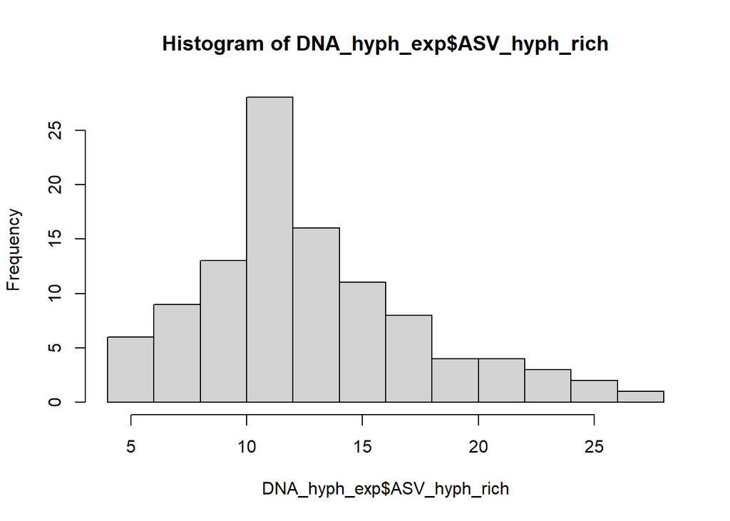

```r
hist(DNA_hyph_exp$ASV_hyph_rich)
```

inspect ASV richness (only hyphomycetes)

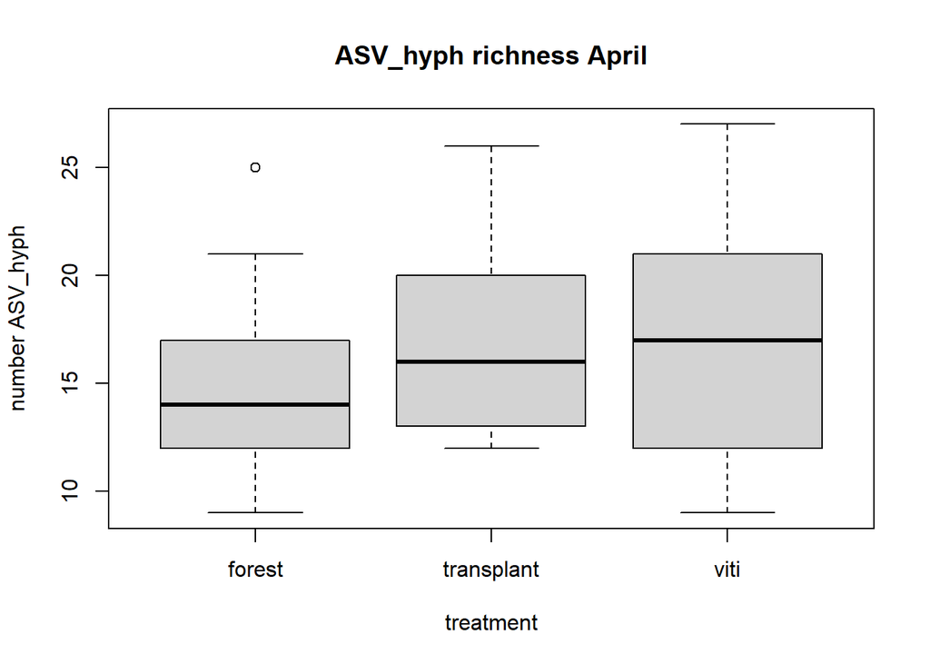

```r
# April
boxplot(DNA_hyph_exp$ASV_hyph_rich[DNA_hyph_exp$timepoint=="April"] ~ DNA$treatment[DNA_hyph_exp$timepoint=="April"], main = "ASV_hyph richness April", xlab="treatment", ylab = "number ASV_hyph")
```

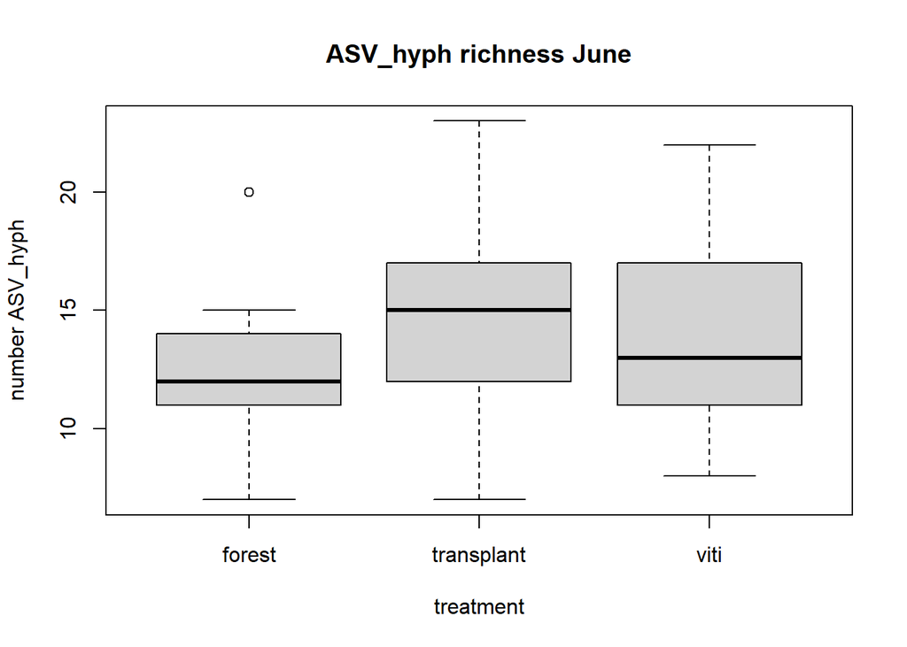

```r
# June
boxplot(DNA_hyph_exp$ASV_hyph_rich[DNA_hyph_exp$timepoint=="June"] ~ DNA_hyph_exp$treatment[DNA_hyph_exp$timepoint=="June"], main = "ASV_hyph richness June", xlab="treatment", ylab = "number ASV_hyph")
```

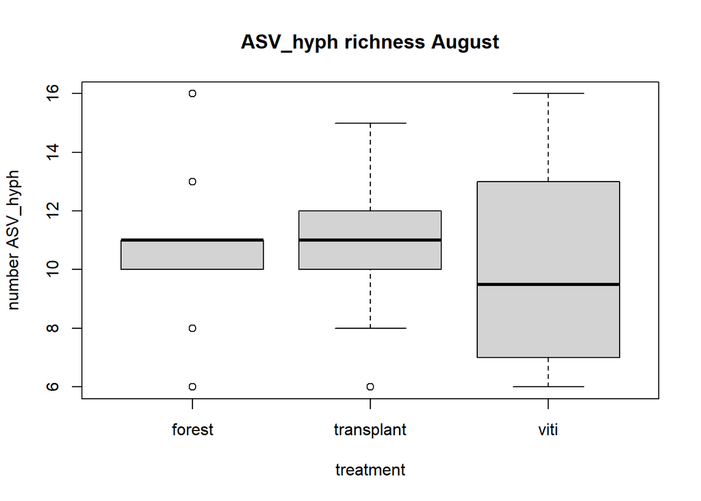

```r
# August
boxplot(DNA_hyph_exp$ASV_hyph_rich[DNA_hyph_exp$timepoint=="August"] ~ DNA_hyph_exp$treatment[DNA_hyph_exp$timepoint=="August"], main = "ASV_hyph richness August", xlab="treatment", ylab = "number ASV_hyph")
```

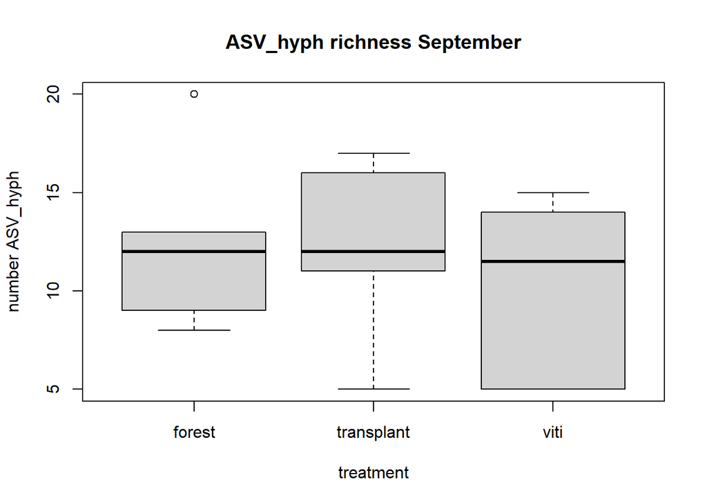

```r
# September
boxplot(DNA_hyph_exp$ASV_hyph_rich[DNA_hyph_exp$timepoint=="September"] ~ DNA_hyph_exp$treatment[DNA_hyph_exp$timepoint=="September"], main = "ASV_hyph richness September", xlab="treatment", ylab = "number ASV_hyph")
```

```r
ASV_hyph_inter <- lsmeans(ASV_hyph_lmer2, ~ treatment | timepoint )

ASV_hyph_inter_dunn1 <- contrast(ASV_hyph_inter, 'pairwise')
(ASV_hyph_inter_dunn_sum1 <- summary(ASV_hyph_inter_dunn1, infer = TRUE, adjust = 'mvt'))
```

```
## timepoint = April:
##  contrast            estimate     SE  df asymp.LCL asymp.UCL z.ratio p.value
##  forest - transplant  -0.0887 0.0660 Inf    -0.243    0.0661  -1.344  0.3710
##  forest - viti        -0.0418 0.0668 Inf    -0.198    0.1148  -0.626  0.8060
##  transplant - viti     0.0469 0.0653 Inf    -0.106    0.2000   0.718  0.7526
##
## timepoint = June:
##  contrast            estimate     SE  df asymp.LCL asymp.UCL z.ratio p.value
##  forest - transplant  -0.0887 0.0660 Inf    -0.243    0.0660  -1.344  0.3709
##  forest - viti        -0.0418 0.0668 Inf    -0.198    0.1147  -0.626  0.8060
##  transplant - viti     0.0469 0.0653 Inf    -0.106    0.1999   0.718  0.7526
##
## timepoint = August:
##  contrast            estimate     SE  df asymp.LCL asymp.UCL z.ratio p.value
##  forest - transplant  -0.0887 0.0660 Inf    -0.243    0.0660  -1.344  0.3710
##  forest - viti        -0.0418 0.0668 Inf    -0.198    0.1147  -0.626  0.8060
##  transplant - viti     0.0469 0.0653 Inf    -0.106    0.2000   0.718  0.7526
##
## timepoint = September:
##  contrast            estimate     SE  df asymp.LCL asymp.UCL z.ratio p.value
##  forest - transplant  -0.0887 0.0660 Inf    -0.243    0.0660  -1.344  0.3710
##  forest - viti        -0.0418 0.0668 Inf    -0.198    0.1147  -0.626  0.8060
##  transplant - viti     0.0469 0.0653 Inf    -0.106    0.2000   0.718  0.7526
##
## Results are given on the log (not the response) scale.
## Confidence level used: 0.95
## Conf-level adjustment: mvt method for 3 estimates
## P value adjustment: mvt method for 3 tests
```

all timepoints no significant difference

```r
ASV_hyph_inter2 <- lsmeans(ASV_hyph_lmer2, ~ timepoint) # reduced comparison, since neither interaction nor treatment were significant

ASV_hyph_inter_dunn2 <- contrast(ASV_hyph_inter2, 'pairwise')
(ASV_hyph_inter_dunn_sum2 <- summary(ASV_hyph_inter_dunn2, infer = TRUE, adjust = 'mvt'))
```

```
##  contrast           estimate     SE  df asymp.LCL asymp.UCL z.ratio p.value
##  April - June          0.176 0.0686 Inf  9.57e-05     0.352   2.563  0.0499
##  April - August        0.438 0.0723 Inf  2.53e-01     0.623   6.058  <.0001
##  April - September     0.336 0.0858 Inf  1.16e-01     0.556   3.917  0.0005
##  June - August         0.262 0.0764 Inf  6.63e-02     0.458   3.429  0.0033
##  June - September      0.160 0.0889 Inf -6.75e-02     0.388   1.802  0.2691
##  August - September   -0.102 0.0921 Inf -3.38e-01     0.134  -1.105  0.6838
##
## Results are averaged over the levels of: treatment
## Results are given on the log (not the response) scale.
## Confidence level used: 0.95
## Conf-level adjustment: mvt method for 6 estimates
## P value adjustment: mvt method for 6 tests
```

#### 3.2.5.1 create Figure S6 c

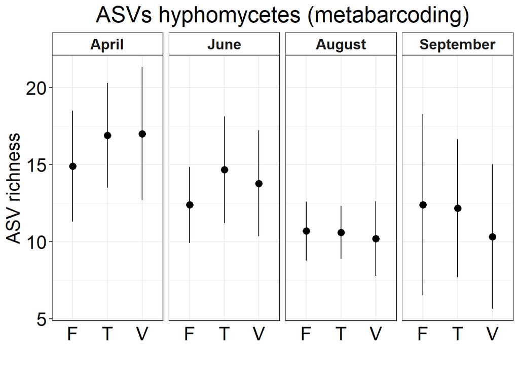

```r
ASV_hyph_CI <- group.CI(ASV_hyph_rich ~ timepoint + treatment,
                   data = DNA_hyph_exp,
                   ci = 0.95)

# change order of factor
ASV_hyph_CI$time.point <- factor(ASV_hyph_CI$timepoint,
                             levels = c("April", "June", "August", "September"))

# rename transplant treatments in order to enable fit to the plot
ASV_hyph_CI$treatment <- gsub("transplant", "T", ASV_hyph_CI$treatment)
ASV_hyph_CI$treatment <- gsub("viti", "V", ASV_hyph_CI$treatment)
ASV_hyph_CI$treatment <- gsub("forest", "F", ASV_hyph_CI$treatment)


p1_ASV_hyph <-  ggplot(ASV_hyph_CI, aes(x = treatment, y = ASV_hyph_rich.mean)) +
  geom_pointrange(data = ASV_hyph_CI, aes(y = ASV_hyph_rich.mean, ymin = ASV_hyph_rich.lower, ymax = ASV_hyph_rich.upper))+
  geom_point(data = ASV_hyph_CI, mapping = aes(y = ASV_hyph_rich.mean), size = 3) +
  facet_wrap(~timepoint, nrow = 1) +
  ylab('ASV richness')+
  xlab("")+
  ggtitle("ASVs hyphomycetes (metabarcoding)")+
  theme_bw()+
  theme(axis.text.x = element_text(size = 18, color="black"), axis.ticks.x = element_blank(),
         axis.text.y = element_text(colour="black", size = 18),
         legend.position="none", strip.text.x = element_text(face = "bold"),
         text = element_text(size=18), plot.title = element_text(hjust = 0.5),strip.background = element_rect(fill="white"))

p1_ASV_hyph
```

### 3.2.6 community composition only hyphomycetes ITS level

#### 3.2.6.1 make Anovas

Create several Anovas with different numbers and composition of explanatory variables, to be able to calculate effects sizes and p-values individually for each explanatory variable.

```r
DNA_taxa_hyph <- DNA_taxasumall[-c(1:3)]

rda_DNA_taxa_hyph_1 <- rda(decostand(DNA_taxa_hyph, "hellinger")
                        ~ timepoint +  Condition(Stream), data = DNA_expl)
summary(rda_DNA_taxa_hyph_1, display = NULL)
```

```
##
## Call:
## rda(formula = decostand(DNA_taxa_hyph, "hellinger") ~ timepoint +      Condition(Stream), data = DNA_expl)
##
## Partitioning of variance:
##               Inertia Proportion
## Total         0.46401     1.0000
## Conditioned   0.15112     0.3257
## Constrained   0.08753     0.1886
## Unconstrained 0.22536     0.4857
##
## Eigenvalues, and their contribution to the variance
## after removing the contribution of conditiniong variables
##
## Importance of components:
##                          RDA1    RDA2     RDA3     PC1     PC2     PC3     PC4
## Eigenvalue            0.07625 0.01011 0.001172 0.08618 0.03418 0.02533 0.01787
## Proportion Explained  0.24370 0.03230 0.003744 0.27542 0.10925 0.08094 0.05711
## Cumulative Proportion 0.24370 0.27601 0.279753 0.55517 0.66442 0.74537 0.80248
##                           PC5     PC6      PC7      PC8      PC9    PC10
## Eigenvalue            0.01498 0.01079 0.008163 0.007662 0.004989 0.00411
## Proportion Explained  0.04789 0.03449 0.026090 0.024489 0.015945 0.01313
## Cumulative Proportion 0.85037 0.88486 0.910950 0.935439 0.951384 0.96452
##                           PC11     PC12     PC13      PC14      PC15      PC16
## Eigenvalue            0.002632 0.001656 0.001084 0.0009684 0.0008962 0.0007927
## Proportion Explained  0.008411 0.005292 0.003465 0.0030951 0.0028642 0.0025334
## Cumulative Proportion 0.972930 0.978221 0.981686 0.9847815 0.9876457 0.9901790
##                            PC17      PC18      PC19      PC20      PC21
## Eigenvalue            0.0006038 0.0004798 0.0004412 0.0003134 0.0002767
## Proportion Explained  0.0019297 0.0015335 0.0014100 0.0010015 0.0008844
## Cumulative Proportion 0.9921088 0.9936422 0.9950522 0.9960537 0.9969382
##                            PC22      PC23      PC24      PC25      PC26
## Eigenvalue            0.0002298 0.0001997 0.0001517 0.0001466 7.355e-05
## Proportion Explained  0.0007344 0.0006384 0.0004848 0.0004687 2.351e-04
## Cumulative Proportion 0.9976725 0.9983109 0.9987957 0.9992643 9.995e-01
##                            PC27      PC28      PC29      PC30      PC31
## Eigenvalue            0.0000452 0.0000355 2.778e-05 2.280e-05 1.571e-05
## Proportion Explained  0.0001445 0.0001134 8.878e-05 7.286e-05 5.022e-05
## Cumulative Proportion 0.9996439 0.9997573 9.998e-01 9.999e-01 1.000e+00
##                            PC32      PC33      PC34
## Eigenvalue            5.742e-06 2.525e-06 1.376e-06
## Proportion Explained  1.835e-05 8.068e-06 4.397e-06
## Cumulative Proportion 1.000e+00 1.000e+00 1.000e+00
##
## Accumulated constrained eigenvalues
## Importance of components:
##                          RDA1    RDA2     RDA3
## Eigenvalue            0.07625 0.01011 0.001172
## Proportion Explained  0.87114 0.11547 0.013384
## Cumulative Proportion 0.87114 0.98662 1.000000
```

```r
anova(rda_DNA_taxa_hyph_1, by = "margin")
```

```
## Permutation test for rda under reduced model
## Marginal effects of terms
## Permutation: free
## Number of permutations: 999
##
## Model: rda(formula = decostand(DNA_taxa_hyph, "hellinger") ~ timepoint + Condition(Stream), data = DNA_expl)
##           Df Variance      F Pr(>F)
## timepoint  3 0.087532 11.911  0.001 ***
## Residual  92 0.225358
## ---
## Signif. codes:  0 '***' 0.001 '**' 0.01 '*' 0.05 '.' 0.1 ' ' 1
```

```r
# timepoint  3 0.087532 11.911  0.001 ***
# 18.9% explained variance (see at summary, proportion constrained)

rda_DNA_taxa_hyph_2 <- rda(decostand(DNA_taxa_hyph, "hellinger")
                        ~ treatment +  Condition(Stream), data = DNA_expl)
summary(rda_DNA_taxa_hyph_2, display = NULL)
```

```
##
## Call:
## rda(formula = decostand(DNA_taxa_hyph, "hellinger") ~ treatment +      Condition(Stream), data = DNA_expl)
##
## Partitioning of variance:
##               Inertia Proportion
## Total         0.46401    1.00000
## Conditioned   0.15112    0.32568
## Constrained   0.03619    0.07798
## Unconstrained 0.27670    0.59633
##
## Eigenvalues, and their contribution to the variance
## after removing the contribution of conditiniong variables
##
## Importance of components:
##                          RDA1      RDA2    PC1     PC2     PC3     PC4     PC5
## Eigenvalue            0.03539 0.0007943 0.1042 0.06136 0.02401 0.01980 0.01547
## Proportion Explained  0.11311 0.0025387 0.3330 0.19612 0.07672 0.06328 0.04944
## Cumulative Proportion 0.11311 0.1156495 0.4487 0.64480 0.72152 0.78480 0.83424
##                           PC6      PC7      PC8      PC9    PC10     PC11
## Eigenvalue            0.01238 0.009636 0.007897 0.005598 0.00474 0.002966
## Proportion Explained  0.03956 0.030798 0.025240 0.017890 0.01515 0.009479
## Cumulative Proportion 0.87380 0.904598 0.929838 0.947728 0.96288 0.972355
##                           PC12     PC13      PC14      PC15     PC16      PC17
## Eigenvalue            0.001841 0.001056 0.0009608 0.0009252 0.000775 0.0006058
## Proportion Explained  0.005883 0.003375 0.0030709 0.0029570 0.002477 0.0019361
## Cumulative Proportion 0.978239 0.981613 0.9846840 0.9876410 0.990118 0.9920539
##                            PC18      PC19     PC20      PC21      PC22
## Eigenvalue            0.0005082 0.0004378 0.000315 0.0002741 0.0002319
## Proportion Explained  0.0016241 0.0013993 0.001007 0.0008760 0.0007413
## Cumulative Proportion 0.9936780 0.9950773 0.996084 0.9969600 0.9977013
##                            PC23      PC24      PC25      PC26      PC27
## Eigenvalue            0.0001948 0.0001546 0.0001354 7.464e-05 4.654e-05
## Proportion Explained  0.0006226 0.0004942 0.0004327 2.386e-04 1.487e-04
## Cumulative Proportion 0.9983239 0.9988181 0.9992508 9.995e-01 9.996e-01
##                            PC28      PC29      PC30      PC31      PC32
## Eigenvalue            3.555e-05 2.809e-05 2.488e-05 1.496e-05 5.728e-06
## Proportion Explained  1.136e-04 8.978e-05 7.951e-05 4.782e-05 1.831e-05
## Cumulative Proportion 9.998e-01 9.998e-01 9.999e-01 1.000e+00 1.000e+00
##                            PC33      PC34
## Eigenvalue            2.649e-06 1.384e-06
## Proportion Explained  8.467e-06 4.422e-06
## Cumulative Proportion 1.000e+00 1.000e+00
##
## Accumulated constrained eigenvalues
## Importance of components:
##                          RDA1      RDA2
## Eigenvalue            0.03539 0.0007943
## Proportion Explained  0.97805 0.0219518
## Cumulative Proportion 0.97805 1.0000000
```

```r
anova(rda_DNA_taxa_hyph_2, by = "margin")
```

```
## Permutation test for rda under reduced model
## Marginal effects of terms
## Permutation: free
## Number of permutations: 999
##
## Model: rda(formula = decostand(DNA_taxa_hyph, "hellinger") ~ treatment + Condition(Stream), data = DNA_expl)
##           Df Variance     F Pr(>F)
## treatment  2 0.036186 6.081  0.001 ***
## Residual  93 0.276705
## ---
## Signif. codes:  0 '***' 0.001 '**' 0.01 '*' 0.05 '.' 0.1 ' ' 1
```

```r
#  treatment  2 0.036186 6.081  0.001 ***
# 7.80 % explained

rda_DNA_taxa_hyph_3 <- rda(decostand(DNA_taxa_hyph, "hellinger")
                        ~ timepoint + treatment +  Condition(Stream), data = DNA_expl)
summary(rda_DNA_taxa_hyph_3, display = NULL)
```

```
##
## Call:
## rda(formula = decostand(DNA_taxa_hyph, "hellinger") ~ timepoint +      treatment + Condition(Stream), data = DNA_expl)
##
## Partitioning of variance:
##               Inertia Proportion
## Total          0.4640     1.0000
## Conditioned    0.1511     0.3257
## Constrained    0.1241     0.2674
## Unconstrained  0.1888     0.4069
##
## Eigenvalues, and their contribution to the variance
## after removing the contribution of conditiniong variables
##
## Importance of components:
##                          RDA1    RDA2     RDA3     RDA4      RDA5     PC1
## Eigenvalue            0.07636 0.03708 0.008754 0.001230 0.0006578 0.06284
## Proportion Explained  0.24406 0.11850 0.027978 0.003931 0.0021022 0.20084
## Cumulative Proportion 0.24406 0.36255 0.390530 0.394461 0.3965636 0.59741
##                           PC2     PC3     PC4     PC5     PC6      PC7      PC8
## Eigenvalue            0.02571 0.02231 0.01728 0.01476 0.01068 0.008025 0.007319
## Proportion Explained  0.08218 0.07129 0.05521 0.04718 0.03414 0.025649 0.023391
## Cumulative Proportion 0.67958 0.75087 0.80608 0.85326 0.88740 0.913051 0.936442
##                            PC9     PC10     PC11     PC12     PC13      PC14
## Eigenvalue            0.004987 0.004099 0.002561 0.001649 0.001048 0.0009586
## Proportion Explained  0.015937 0.013102 0.008185 0.005269 0.003349 0.0030637
## Cumulative Proportion 0.952379 0.965481 0.973666 0.978935 0.982284 0.9853482
##                            PC15     PC16      PC17      PC18      PC19
## Eigenvalue            0.0008659 0.000753 0.0005738 0.0004651 0.0004232
## Proportion Explained  0.0027675 0.002407 0.0018339 0.0014863 0.0013524
## Cumulative Proportion 0.9881157 0.990522 0.9923562 0.9938425 0.9951949
##                            PC20      PC21      PC22      PC23      PC24
## Eigenvalue            0.0003100 0.0002647 0.0002260 0.0001942 0.0001489
## Proportion Explained  0.0009909 0.0008460 0.0007222 0.0006206 0.0004758
## Cumulative Proportion 0.9961858 0.9970318 0.9977540 0.9983747 0.9988505
##                            PC25      PC26      PC27      PC28      PC29
## Eigenvalue            0.0001341 7.314e-05 4.356e-05 0.0000352 2.756e-05
## Proportion Explained  0.0004286 2.338e-04 1.392e-04 0.0001125 8.807e-05
## Cumulative Proportion 0.9992791 9.995e-01 9.997e-01 0.9997645 9.999e-01
##                            PC30      PC31      PC32      PC33      PC34
## Eigenvalue            2.187e-05 1.479e-05 5.608e-06 2.484e-06 1.366e-06
## Proportion Explained  6.989e-05 4.727e-05 1.792e-05 7.940e-06 4.366e-06
## Cumulative Proportion 9.999e-01 1.000e+00 1.000e+00 1.000e+00 1.000e+00
##
## Accumulated constrained eigenvalues
## Importance of components:
##                          RDA1    RDA2     RDA3     RDA4      RDA5
## Eigenvalue            0.07636 0.03708 0.008754 0.001230 0.0006578
## Proportion Explained  0.61543 0.29881 0.070550 0.009913 0.0053010
## Cumulative Proportion 0.61543 0.91424 0.984786 0.994699 1.0000000
```